# DATA 624_Exercises_HA 7.5, 7.6, 7.10

Jeremy O’Brien

September 23, 2019

```r
if (!require('fpp2')) (install.packages('fpp2'))
if (!require('kableExtra')) (install.packages('kableExtra'))
if (!require('dplyr')) (install.packages('dplyr'))

#if (!require('forecast')) (install.packages('forecast'))
#if (!require('tidyr')) (install.packages('tidyr'))
#if (!require('magrittr')) (install.packages('magrittr'))
#if (!require('scales')) (install.packages('scales'))
```

### Exercise 7.5

#### Data set `books` contains the daily sales of paperback and hardcover books at the same store. The task is to forecast the next four days’ sales for paperback and hardcover books.

#### (a) Plot the series and discuss the main features of the data.

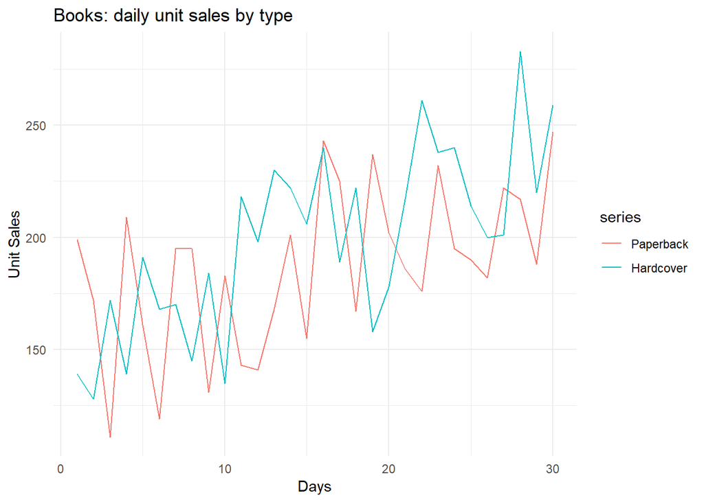

```r
autoplot(books) +
  theme_minimal() +
  labs(title = 'Books: daily unit sales by type',
       y = 'Unit Sales',
       x = 'Days')
```

#### Per the description, daily unit sales of paperback and hardcover books at a single store for 30 days. Both are increasing over the time period, with considerable perturbation day-to-day. While paperbacks and hardcovers both have a similar range of unit salesp, peaks and valleys are not well synchronized.

#### (b) Use the `ses()` function to forecast each series, and plot the forecasts.

```r
# Subset the multivariate time series, extracting only paperback data
paper <- books[,1]

# Create a simple exponential smoothing forecast
fc_paper <- ses(paper, h = 5)

# Output the summary and plot the forecast
summary(fc_paper)
```

```
##
## Forecast method: Simple exponential smoothing
##
## Model Information:
## Simple exponential smoothing
##
## Call:
##  ses(y = paper, h = 5)
##
##   Smoothing parameters:
##     alpha = 0.1685
##
##   Initial states:
##     l = 170.8271
##
##   sigma:  34.8183
##
##      AIC     AICc      BIC
## 318.9747 319.8978 323.1783
##
## Error measures:
##                    ME     RMSE     MAE       MPE     MAPE      MASE
## Training set 7.175981 33.63769 27.8431 0.4736071 15.57784 0.7021303
##                    ACF1
## Training set -0.2117522
##
## Forecasts:
##    Point Forecast    Lo 80    Hi 80    Lo 95    Hi 95
## 31       207.1097 162.4882 251.7311 138.8670 275.3523
## 32       207.1097 161.8589 252.3604 137.9046 276.3147
## 33       207.1097 161.2382 252.9811 136.9554 277.2639
## 34       207.1097 160.6259 253.5935 136.0188 278.2005
## 35       207.1097 160.0215 254.1979 135.0945 279.1249
```

[figure not shown]

```r
autoplot(fc_paper) +
  theme_minimal() +
  labs(title = 'Paperbacks: units sales with four-day SES forecast',
       y = 'Unit Sales',
       x = 'Days')
```

```r
# Subset only for hardcover data
hard <- books[,2]

# Create a simple exponential smoothing forecast
fc_hard <- ses(hard, h = 5)

# Plot the forecast
summary(fc_hard)
```

```
##
## Forecast method: Simple exponential smoothing
##
## Model Information:
## Simple exponential smoothing
##
## Call:
##  ses(y = hard, h = 5)
##
##   Smoothing parameters:
##     alpha = 0.3283
##
##   Initial states:
##     l = 149.2861
##
##   sigma:  33.0517
##
##      AIC     AICc      BIC
## 315.8506 316.7737 320.0542
##
## Error measures:
##                    ME     RMSE      MAE      MPE     MAPE      MASE
## Training set 9.166735 31.93101 26.77319 2.636189 13.39487 0.7987887
##                    ACF1
## Training set -0.1417763
##
## Forecasts:
##    Point Forecast    Lo 80    Hi 80    Lo 95    Hi 95
## 31       239.5601 197.2026 281.9176 174.7799 304.3403
## 32       239.5601 194.9788 284.1414 171.3788 307.7414
## 33       239.5601 192.8607 286.2595 168.1396 310.9806
## 34       239.5601 190.8347 288.2855 165.0410 314.0792
## 35       239.5601 188.8895 290.2306 162.0662 317.0540
```

[figure not shown]

```r
autoplot(fc_hard)  +
  theme_minimal() +
  labs(title = 'Hardcovers: units sales with four-day SES forecast',
       y = 'Unit Sales',
       x = 'Days')
```

#### (c) Compute the RMSE values for the training data in each case.

```r
cat('\n Paperback forecast RMSE = ', round(accuracy(fc_paper)[2], 2))
```

```
##
##  Paperback forecast RMSE =  33.64
```

```r
cat('\n Hardcover forecast RMSE = ', round(accuracy(fc_hard)[2], 2))
```

```
##
##  Hardcover forecast RMSE =  31.93
```

#### Exercise 7.6

#### (a) Now apply Holt’s linear method to the `paperback` and `hardback` series and compute four-day forecasts in each case.

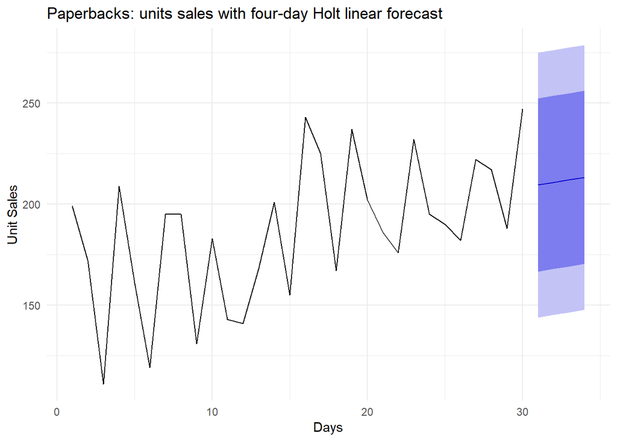

```r
# Apply linear method with four-day forecast for paperbacks
fc_h_paper <- holt(paper, h = 4)

# Same for hardcovers
fc_h_hard <- holt(hard, h = 4)

# Plot the forecasts
autoplot(fc_h_paper) +
  theme_minimal() +
  labs(title = 'Paperbacks: units sales with four-day Holt linear forecast',
       y = 'Unit Sales',
       x = 'Days')
```

[figure not shown]

```r
autoplot(fc_h_hard) +
  theme_minimal() +
  labs(title = 'Paperbacks: units sales with four-day Holt linear forecast',
       y = 'Unit Sales',
       x = 'Days')
```

#### With the linear method, the clear positive trend is taken into account for both the paperback and hardcover time series, with hardcover demonstrating a steeper slope in the forecast.

#### (b) Compare the RMSE measures of Holt’s method for the two series to those of simple exponential smoothing in the previous question. (Remember that Holt’s method is using one more parameter than SES.) Discuss the merits of the two forecasting methods for these data sets.

```r
cat('\n Paperback Holt linear forecast RMSE = ', round(accuracy(fc_h_paper)[2], 2))
```

```
##
##  Paperback Holt linear forecast RMSE =  31.14
```

```r
cat('\n Hardcover Holt linear forecast RMSE = ', round(accuracy(fc_h_hard)[2], 2))
```

```
##
##  Hardcover Holt linear forecast RMSE =  27.19
```

#### The RMSE values using Holt’s method are slightly lower than for SES, indicating that this model accounts for more variance. SES does not address the 30-day upward trend in both series and thus leaves some important information out in this case.

#### (c) Compare the forecasts for the two series using both methods. Which do you think is best?

#### Given the visual evidence of a 30-day upward trend, including a trend parameter with Holt’s linear method is likely to provide a better forecast.

#### (d) Calculate a 95% prediction interval for the first forecast for each series, using the RMSE values and assuming normal errors. Compare your intervals with those produced using `ses` and `holt`.

```r
# For paperbacks, call mean prediction of SES and compute upper and lower values of interval
fc_interv_paper <- c((fc_paper$mean[1] - sd(fc_paper$residuals) * 1.96),
             (fc_paper$mean[1] + sd(fc_paper$residuals) * 1.96))

fc_h_interv_paper <- c((fc_h_paper$mean[1] - sd(fc_h_paper$residuals) * 1.96),
             (fc_h_paper$mean[1] + sd(fc_h_paper$residuals) * 1.96))

cat('\n Paperback SES low forecast = ', scales::comma(fc_paper$lower[5]),
    '\n Paperback Holt linear low forecast = ', scales::comma(fc_h_paper$lower[5]),
    '\n Paperback manual SES low forecast = ', scales::comma(fc_interv_paper[1]),
    '\n Paperback manual SES Holt linear low forecast = ', scales::comma(fc_h_interv_paper[1]))
```

```
##
##  Paperback SES low forecast =  160
##  Paperback Holt linear low forecast =  144
##  Paperback manual SES low forecast =  142
##  Paperback manual SES Holt linear low forecast =  148
```

```r
fc_interv_hard <- c((fc_hard$mean[1] - sd(fc_hard$residuals) * 1.96),
             (fc_hard$mean[1] + sd(fc_hard$residuals) * 1.96))

fc_h_interv_hard <- c((fc_h_hard$mean[1] - sd(fc_h_hard$residuals) * 1.96),
             (fc_h_hard$mean[1] + sd(fc_h_hard$residuals) * 1.96))

cat('\n \n Hardcover SES low forecast = ', scales::comma(fc_hard$lower[5]),
    '\n Hardcover Holt linear low forecast = ', scales::comma(fc_h_hard$lower[5]),
    '\n Hardcover manual low forecast = ', scales::comma(fc_interv_hard[1]),
    '\n Hardcover manual SES Holt linear low forecast = ', scales::comma(fc_h_interv_paper[1]))
```

[output not shown]

### Exercise 7.10

#### For this exercise use the dataset `ukcars`, the quarterly UK passenger vehicle production data from 1977Q1-2005Q1.

#### (a) Plot the data and describe the main features of the series.

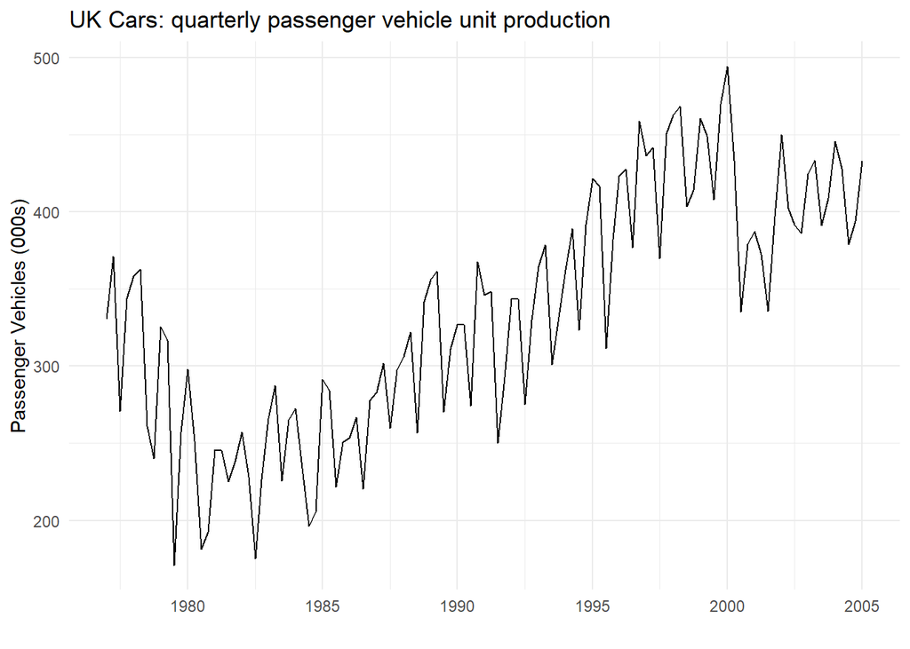

```r
data(ukcars)
autoplot(ukcars) +
  theme_minimal() +
  labs(title = 'UK Cars: quarterly passenger vehicle unit production',
       y = 'Passenger Vehicles (000s)',
       x = '')
```

#### This quarterly data shows seeming seasonal variation. It does not, however, evince a consistent trend - it moves downward pre-1980 before turning back upward from 1982 until the milennium. at which time it drops to 1995 levels and plateaues.

#### (b) Decompose the series using STL and obtain the seasonally adjusted data.

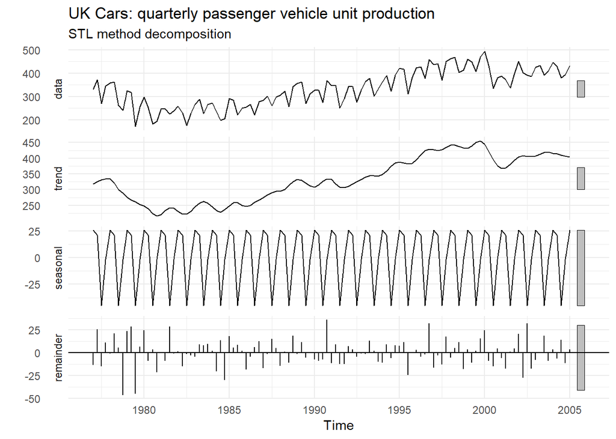

```r
fit_stl_ukcars <- stl(ukcars, s.window = 'periodic')
autoplot(fit_stl_ukcars) +
  theme_minimal() +
  labs(title = 'UK Cars: quarterly passenger vehicle unit production',
       subtitle = 'STL method decomposition')
```

#### (c) Forecast the next two years of the series using an additive damped trend method applied to the seasonnaly adjusted data. (This can be done in one step using `stlf()` with arguments etsmodel = AAN, damped = TRUE)

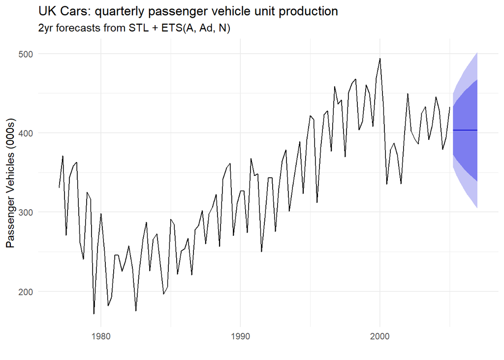

```r
# Forecast additive damped trend (A_dN) with stlf
fc_adn_ukcars <- stlf(ukcars,
                      h = 8,
                      etsmodel = 'AAN',
                      damped = TRUE)
autoplot(fc_adn_ukcars) +
  theme_minimal() +
  labs(title = 'UK Cars: quarterly passenger vehicle unit production',
       subtitle = '2yr forecasts from STL + ETS(A, Ad, N)',
       y = 'Passenger Vehicles (000s)',
       x = '')
```

```r
fc8q_adn_ukcars <-
  summary(fc_adn_ukcars) %>%
  as.data.frame() %>%
  select(`Point Forecast`) %>%
  rename('A_dN' = 'Point Forecast')
```

```
##
## Forecast method: STL +  ETS(A,Ad,N)
##
## Model Information:
## ETS(A,Ad,N)
##
## Call:
##  ets(y = x, model = etsmodel, damped = TRUE, allow.multiplicative.trend = allow.multiplicative.trend)
##
##   Smoothing parameters:
##     alpha = 0.7037
##     beta  = 1e-04
##     phi   = 0.9243
##
##   Initial states:
##     l = 341.6239
##     b = -5.0799
##
##   sigma:  23.8549
##
##      AIC     AICc      BIC
## 1257.950 1258.743 1274.314
##
## Error measures:
##                    ME     RMSE      MAE        MPE     MAPE     MASE
## Training set 1.551267 23.32113 18.48987 0.04121971 6.042764 0.602576
##                    ACF1
## Training set 0.02262668
##
## Forecasts:
##         Point Forecast    Lo 80    Hi 80    Lo 95    Hi 95
## 2005 Q2       403.1624 372.5912 433.7336 356.4077 449.9171
## 2005 Q3       403.1613 365.7770 440.5457 345.9869 460.3357
## 2005 Q4       403.1603 360.0246 446.2960 337.1900 469.1307
## 2006 Q1       403.1594 354.9527 451.3662 329.4335 476.8853
## 2006 Q2       403.1586 350.3647 455.9524 322.4173 483.8998
## 2006 Q3       403.1578 346.1439 460.1716 315.9626 490.3530
## 2006 Q4       403.1570 342.2140 464.1001 309.9527 496.3614
## 2007 Q1       403.1564 338.5220 467.7907 304.3067 502.0061
```

```r
fc8q_adn_ukcars %>%
  kable()
```

|  | A_dN |
| --- | --- |
| 2005 Q2 | 403.1624 |
| 2005 Q3 | 403.1613 |
| 2005 Q4 | 403.1603 |
| 2006 Q1 | 403.1594 |
| 2006 Q2 | 403.1586 |
| 2006 Q3 | 403.1578 |
| 2006 Q4 | 403.1570 |
| 2007 Q1 | 403.1564 |

#### (d) Forecast the next two year of the series using Holt’s linear method applied to the seasonally adjusted data (as before but with `damped = FALSE`)

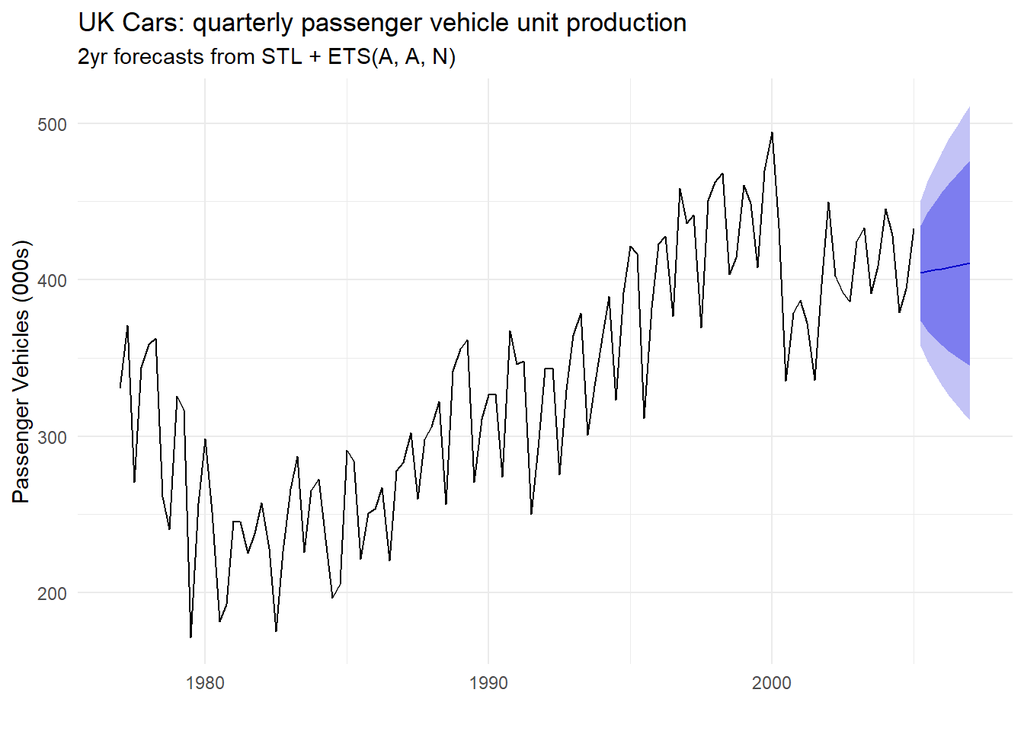

```r
# Forecast Holt's linear method (AN)
fc_an_ukcars <- stlf(ukcars,
                       h = 8,
                       etsmodel = 'AAN',
                       damped = FALSE)
autoplot(fc_an_ukcars) +
  theme_minimal() +
  labs(title = 'UK Cars: quarterly passenger vehicle unit production',
       subtitle = '2yr forecasts from STL + ETS(A, A, N)',
       y = 'Passenger Vehicles (000s)',
       x = '')
```

```r
fc8q_an_ukcars <-
  summary(fc_an_ukcars) %>%
  as.data.frame() %>%
  select(`Point Forecast`) %>%
  rename('AN' = 'Point Forecast')
```

```
##
## Forecast method: STL +  ETS(A,A,N)
##
## Model Information:
## ETS(A,A,N)
##
## Call:
##  ets(y = x, model = etsmodel, damped = FALSE, allow.multiplicative.trend = allow.multiplicative.trend)
##
##   Smoothing parameters:
##     alpha = 0.7248
##     beta  = 1e-04
##
##   Initial states:
##     l = 328.1086
##     b = 0.9202
##
##   sigma:  23.7186
##
##      AIC     AICc      BIC
## 1255.697 1256.258 1269.334
##
## Error measures:
##                      ME   RMSE     MAE        MPE    MAPE      MASE
## Training set -0.3412727 23.295 18.1605 -0.5970778 5.98018 0.5918418
##                    ACF1
## Training set 0.02103582
##
## Forecasts:
##         Point Forecast    Lo 80    Hi 80    Lo 95    Hi 95
## 2005 Q2       404.3251 373.9285 434.7216 357.8375 450.8126
## 2005 Q3       405.2414 367.6977 442.7850 347.8233 462.6594
## 2005 Q4       406.1577 362.6234 449.6919 339.5778 472.7376
## 2006 Q1       407.0740 358.2778 455.8702 332.4466 481.7014
## 2006 Q2       407.9903 354.4455 461.5351 326.1006 489.8800
## 2006 Q3       408.9066 351.0002 466.8130 320.3464 497.4668
## 2006 Q4       409.8229 347.8601 471.7858 315.0589 504.5869
## 2007 Q1       410.7392 344.9686 476.5098 310.1518 511.3267
```

```r
fc8q_an_ukcars %>%
  kable()
```

|  | AN |
| --- | --- |
| 2005 Q2 | 404.3251 |
| 2005 Q3 | 405.2414 |
| 2005 Q4 | 406.1577 |
| 2006 Q1 | 407.0740 |
| 2006 Q2 | 407.9903 |
| 2006 Q3 | 408.9066 |
| 2006 Q4 | 409.8229 |
| 2007 Q1 | 410.7392 |

#### (e) Now use `ets()` to choose a seasonal model for the data.

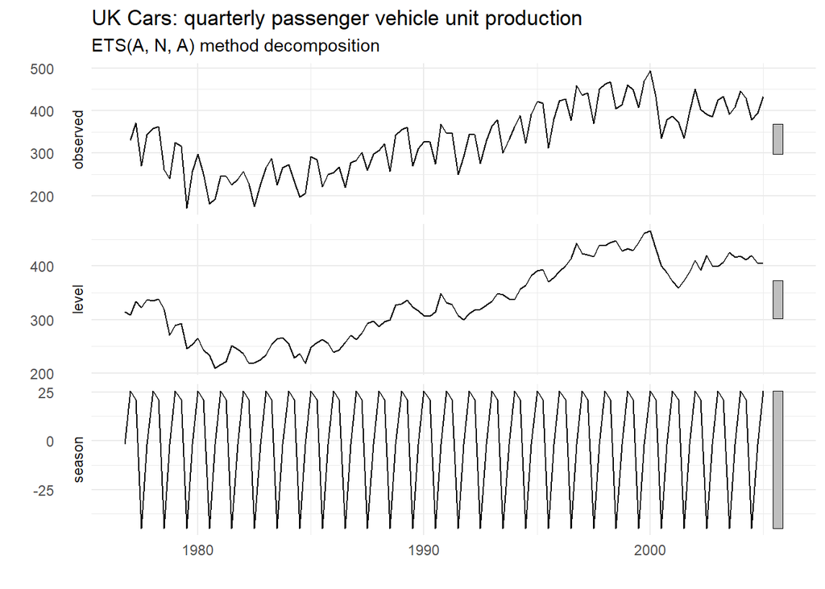

```r
# additive errors, no trend, additive seasonal method
fit_ana_ukcars <- ets(ukcars,
                     model = 'ZZZ',  # obtain model by minimizing AIC_c
                     damped = NULL,
                     alpha = NULL,
                     beta = NULL,
                     gamma = NULL,
                     phi = NULL,
                     lambda = NULL,
                     additive.only = TRUE,
                     restrict = TRUE,
                     allow.multiplicative.trend = FALSE)

# Estimated states over time
autoplot(fit_ana_ukcars) +
  theme_minimal() +
  labs(title = 'UK Cars: quarterly passenger vehicle unit production',
       subtitle = 'ETS(A, N, A) method decomposition')
```

#### We should choose a seasonal additive model as seasonal variation does not appear to grow multiplicatively over time.

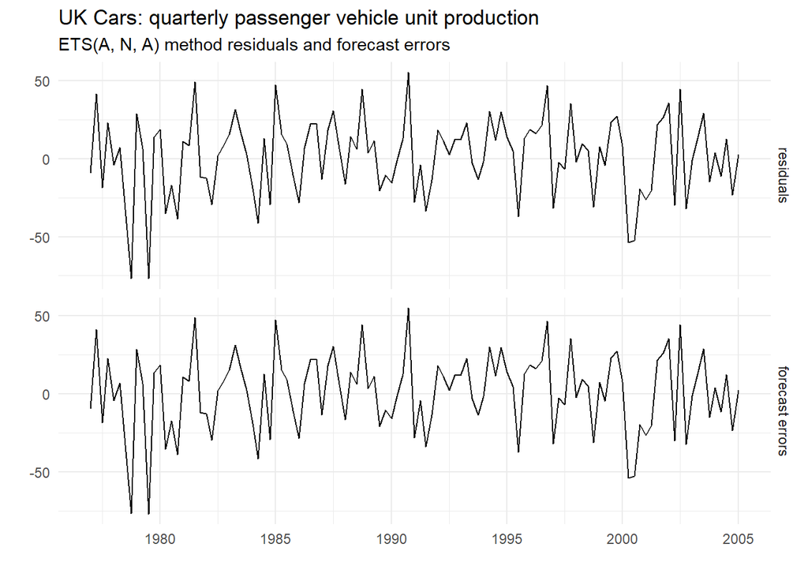

```r
# Because additive, residuals are equal to one-step training errors
cbind('residuals' = residuals(fit_ana_ukcars),
      'forecast errors' = residuals(fit_ana_ukcars, type = 'response')) %>%
  autoplot(facet = TRUE) +
  theme_minimal() +
  labs(title = 'UK Cars: quarterly passenger vehicle unit production',
       subtitle = 'ETS(A, N, A) method residuals and forecast errors',
       x = '',
       y = '')
```

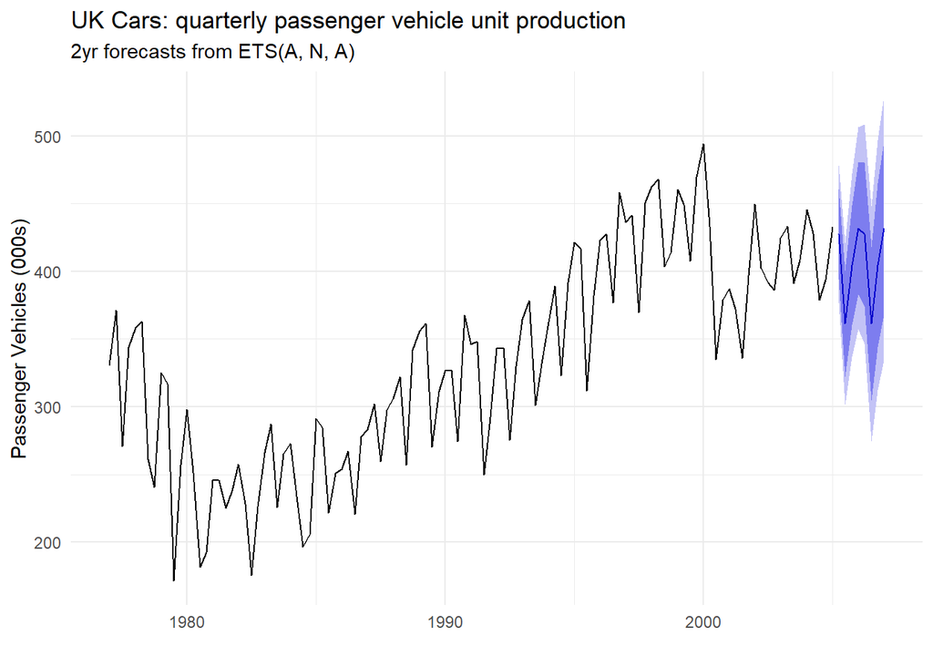

```r
fc_ana_ukcars <- fit_ana_ukcars %>%
  forecast(h = 8)

fc_ana_ukcars %>%
  autoplot() +
  theme_minimal() +
  labs(title = 'UK Cars: quarterly passenger vehicle unit production',
       subtitle = '2yr forecasts from ETS(A, N, A)',
       y = 'Passenger Vehicles (000s)',
       x = '')
```

```r
fc8q_ana_ukcars <-
  summary(fc_ana_ukcars) %>%
  as.data.frame() %>%
  select(`Point Forecast`) %>%
  rename('ANA' = 'Point Forecast')
```

```
##
## Forecast method: ETS(A,N,A)
##
## Model Information:
## ETS(A,N,A)
##
## Call:
##  ets(y = ukcars, model = "ZZZ", damped = NULL, alpha = NULL, beta = NULL,
##
##  Call:
##      gamma = NULL, phi = NULL, additive.only = TRUE, lambda = NULL,
##
##  Call:
##      restrict = TRUE, allow.multiplicative.trend = FALSE)
##
##   Smoothing parameters:
##     alpha = 0.6199
##     gamma = 1e-04
##
##   Initial states:
##     l = 314.2568
##     s = -1.7579 -44.9601 21.1956 25.5223
##
##   sigma:  25.9302
##
##      AIC     AICc      BIC
## 1277.752 1278.819 1296.844
##
## Error measures:
##                    ME     RMSE      MAE        MPE     MAPE      MASE
## Training set 1.313884 25.23244 20.17907 -0.1570979 6.629003 0.6576259
##                    ACF1
## Training set 0.02573334
##
## Forecasts:
##         Point Forecast    Lo 80    Hi 80    Lo 95    Hi 95
## 2005 Q2       427.4885 394.2576 460.7195 376.6662 478.3109
## 2005 Q3       361.3329 322.2353 400.4305 301.5383 421.1275
## 2005 Q4       404.5358 360.3437 448.7280 336.9497 472.1219
## 2006 Q1       431.8154 383.0568 480.5741 357.2455 506.3854
## 2006 Q2       427.4885 374.5571 480.4200 346.5369 508.4401
## 2006 Q3       361.3329 304.5345 418.1313 274.4672 448.1986
## 2006 Q4       404.5358 344.1174 464.9542 312.1338 496.9378
## 2007 Q1       431.8154 367.9809 495.6500 334.1890 529.4419
```

```r
fc8q_ana_ukcars %>%
  kable()
```

|  | ANA |
| --- | --- |
| 2005 Q2 | 427.4885 |
| 2005 Q3 | 361.3329 |
| 2005 Q4 | 404.5358 |
| 2006 Q1 | 431.8154 |
| 2006 Q2 | 427.4885 |
| 2006 Q3 | 361.3329 |
| 2006 Q4 | 404.5358 |
| 2007 Q1 | 431.8154 |

#### (f) Compare the RMSE of the ETS model with the RMSE of the models you obtained using STL decompositions. Which gives the better in-sample fits?

```r
cat('\n Additive error additive damped trend no seasonal RMSE = ', round(accuracy(fc_adn_ukcars)[2], 2))
```

```
##
##  Additive error additive damped trend no seasonal RMSE =  23.32
```

```r
cat('\n Additive error additive seasonal RMSE = ', round(accuracy(fc_an_ukcars)[2], 2))
```

[output not shown]

```r
cat('\n Additive error, forecast RMSE = ', round(accuracy(fc_ana_ukcars)[2], 2))
```

```
##
##  Additive error, forecast RMSE =  25.23
```

#### (g) Compare the forecasts from the three approaches. Which seems most reasonable?

```r
fc_compare <- cbind(fc8q_adn_ukcars, fc8q_an_ukcars, fc8q_ana_ukcars)

fc_compare %>%
  kable()
```

|  | A_dN | AN | ANA |
| --- | --- | --- | --- |
| 2005 Q2 | 403.1624 | 404.3251 | 427.4885 |
| 2005 Q3 | 403.1613 | 405.2414 | 361.3329 |
| 2005 Q4 | 403.1603 | 406.1577 | 404.5358 |
| 2006 Q1 | 403.1594 | 407.0740 | 431.8154 |
| 2006 Q2 | 403.1586 | 407.9903 | 427.4885 |
| 2006 Q3 | 403.1578 | 408.9066 | 361.3329 |
| 2006 Q4 | 403.1570 | 409.8229 | 404.5358 |
| 2007 Q1 | 403.1564 | 410.7392 | 431.8154 |

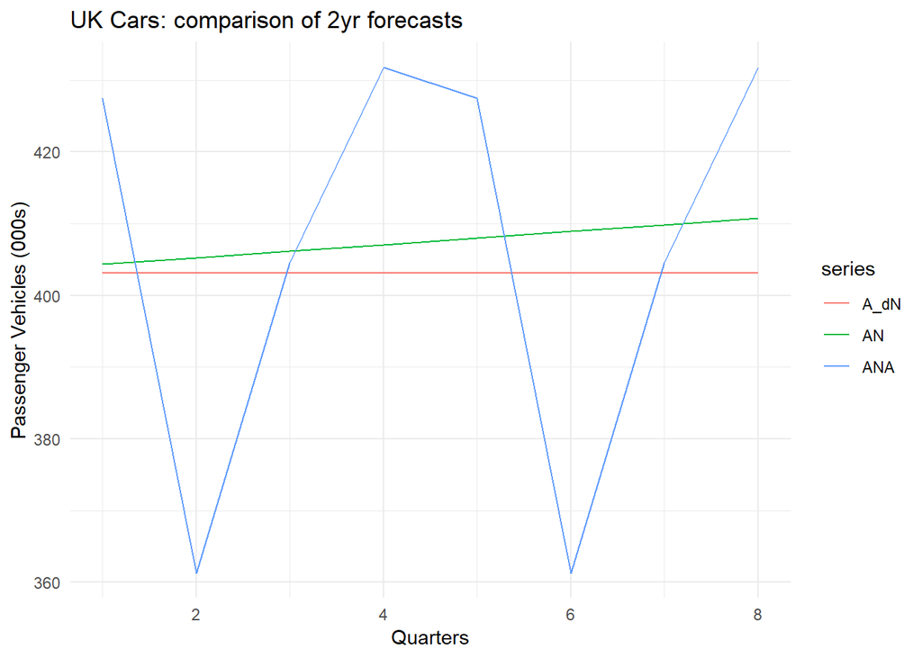

```r
fc_3ts <- ts(fc_compare)

autoplot(fc_3ts) +
  theme_minimal() +
  labs(title = 'UK Cars: comparison of 2yr forecasts',
       y = 'Passenger Vehicles (000s)',
       x = 'Quarters')
```

#### (h) Check the residuals of your preferred model.

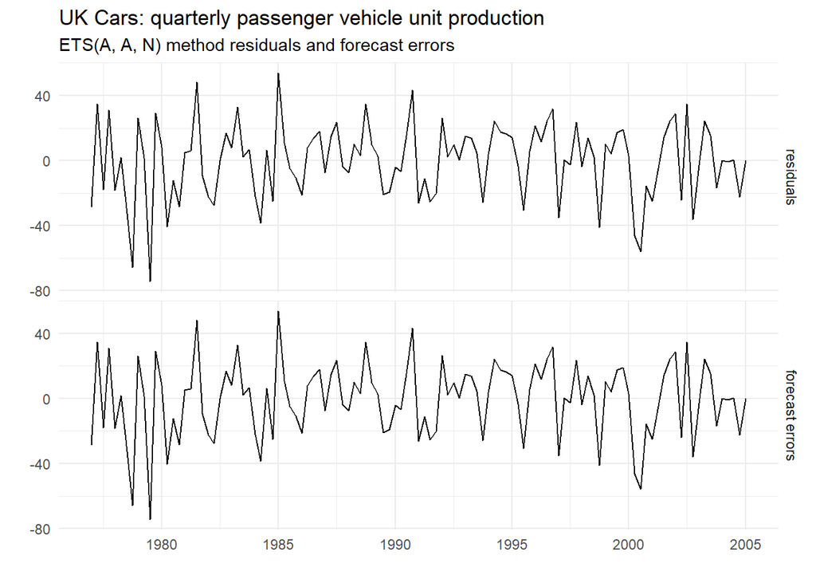

```r
# Because additive, residuals are equal to one-step training errors
cbind('residuals' = residuals(fc_an_ukcars),
      'forecast errors' = residuals(fc_an_ukcars, type = 'response')) %>%
  autoplot(facet = TRUE) +
  theme_minimal() +
  labs(title = 'UK Cars: quarterly passenger vehicle unit production',
       subtitle = 'ETS(A, A, N) method residuals and forecast errors',
       x = '',
       y = '')
```